# Crecimiento geométrico

20 de febrero de 2019

## Crecimiento geométrico

## Contenidos

- Las poblaciones como un sistemas
- Las dos grandes modelos de la ecología de poblaciones
- Teoría del crecimiento geométrico
- Modificaciones al programa de estudio
- Dudas con instalación del ambiente de trabajo
- Ambiente **RStudio**, y repaso del tutorial con **R**.
- Metas para la próxima semana

## Sistemas

## Población como un sistema

- Un sistema es un conjunto de partes, cada una con cierta funcionalidad, que son esenciales para el funcionamiento de las otras partes del sistema.
- Un sistema puede ser definido, de acuerdo a una escala. Por tanto, para una determinada escala se define un sistema, y todo lo que queda por fuera, se le denomina ambiente.
- Una población es un sistema de individuos de la misma especie que interaccionan y se intercomunican entre sí, y que coexisten dentro de cierta zona geográfica.

Berryman, A. A., & Kindlmann, P. (2008). Population systems: a general introduction. Population (English Edition) (2nd ed.). Springer.

## Población como sistema

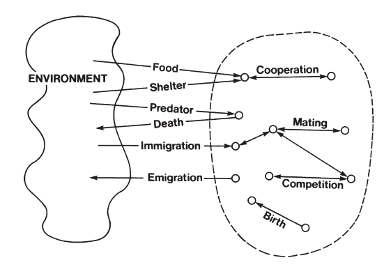

Población como sistema

## Dinámica del sistema

- Las partes de un sistema se regulan entre sí.
- En la regulación de un sistema, pueden intervenir las **entradas** del ambiente. Pero el sistema puede tener efecto sobre el ambiente mediante sus **salidas**.
- Una "foto" del sistema, se conoce como **estado del sistema**.
- Una *variable dentro del sistema* que este propensa a cambiar, y que sea utilizada para describir el sistema, se conoce como **variable de estado** (*state variable*). Por ejemplo, una distribución de edades.
- Una variable que afecte el proceso que la genera, se dice que tiene **retroalimentación**. Por ejemplo, la *carrera armamentista* entre depredador y presa.

## Dinámica del sistema

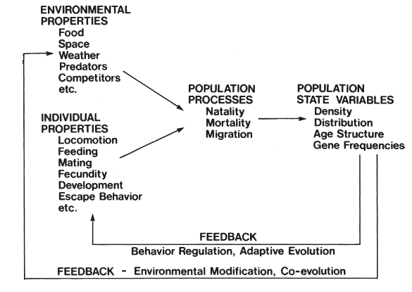

## Ecología de poblaciones

> Berryman y Kindlmann (2008), nos exhortan a pensar que la *Ecología de Poblaciones* es un proceso de ingeniería inversa, donde el sistema existe, y nos interesa saber cómo funciona.

[figure not shown]

## Los dos grandes Modelos de la Ecología de poblaciones

- Modelos basados en individuos (agentes): IBM
- Simulan la interacción de componentes individuales en un sistema y analizan los patrones generales.
- [Colección de modelos](https://www.red3d.com/cwr/ibm.html).
- [The nature of code](https://natureofcode.com/). Buena introducción a la programación de objetos y sistemas. [Videos de los capítulos](https://www.youtube.com/user/shiffman/playlists?shelf_id=6&view=50&sort=dd).
- [Libro IBM](http://www2.humboldt.edu/ecomodel/documents/Grimm-Railsback05.pdf).
- Modelos Poblacionales (\(N\))
- Expresiones matemáticas

## ¿Por qué crecen las poblaciones?

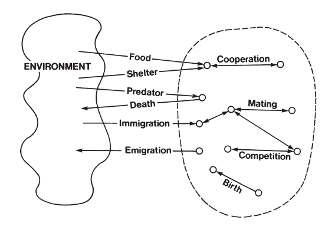

Población como sistema

## ¿Por qué crecen las poblaciones?

- Los organismos no viven eternamente. Siempre existe mortalidad.
- Debido a la mortalidad, los individuos deben dejar descendencia.
- Las poblaciones deben amortiguar el efecto de los individuos que no se reproducen.
- La teoría de la Evolución exige una cantidad de individuos, de donde se toma un *pool* de variación genética.

## Deducción del crecimiento geométrico

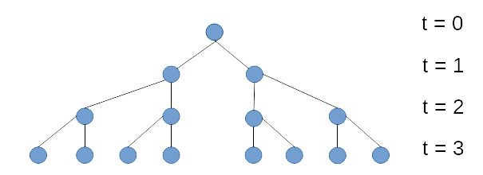

Crecimiento geométrico

¿Cuánto crece \(N_{t+1}\) con relación a \(N_t\)?

## Deducción del crecimiento geométrico

- \(\frac{N_{t+1}}{N_t} = 2\)
- \(N_{t+1} = 2\,N_t\)
- \(N_2 = \ ?\)

## Deducción del crecimiento geométrico

- \(N_2 = 2\, N_1\)
- \(N_2 = 2\, (2\, N_0)\)
- \(N_3 = \ ?\)
- \(N_n = \ ?\)

## Logramos

\[ N_n = 2^n N_0 \]

## Deducción generalizada

## Cambios y razones de cambio

¿Cómo expresaría el cambio de \(N_2\) a \(N_1\)?

- \(N_2 - N_1\)
- \(N_2 - N_1 = \Delta N\)
- ¿Cómo expresaría este cambio, en un intervalo de tiempo?
- \(\frac{N_2 - N_1}{t_2 - t_1}\)
- \(\frac{\Delta N}{\Delta t}\)

## Exprese en palabras, una ecuación que explique el cambio en el tamaño de una población

- Cambio en una población, en un momento determinado, equivale a las entradas en la población menos las salidas de la misma.
- \(\frac{\Delta N}{\Delta t} = B - D\)
- ¿Qué propiedades observa en esta ecuación?

## Crecimiento Geométrico: Desarrollo 1

Si dividimos la ecuación anterior por \(N\) para conocer el cambio poblacional *per capita*, tenemos:

\[ \frac{\Delta N / \Delta t}{N} = \frac{B - D}{N} \]

Asumiendo que la diferencia entre *natalidad* (\(B\)) y *mortalidad* (\(D\)) se mantenga constante, reemplazamos el lado derecho por una constante: \(\mathrm{R_m}\), la tasa de crecimiento por individuo.

\[ \frac{\Delta N / \Delta t}{N} = \mathrm{R_m} \]

## Crecimiento Geométrico: Desarrollo 2

Multiplicando ambos lados por \(N\):

\[ \frac{\Delta N }{\Delta t} = \mathrm{R_m} N \]

¿Cuáles son las propiedades de \(\mathrm{R_m}\)? ¿Qué pasa cuando es grande, cercano a cero o negativo?

**En palabras, exprese una ecuación que relacione \(N_1\) con \(N_0\), usando lo que sabemos hasta ahora**

## Crecimiento Geométrico: Desarrollo 3

*El tamaño de población de este año es igual a la del año anterior más el crecimiento en ese periodo de tiempo*

\[ N_{t} = N_{t-1} + \frac{\Delta N }{\Delta t} = N_{t-1} + \mathrm{R_m} N_{t-1} \]

Note que podemos escribir:

\[ N_1 = N_0 \left( 1 + \mathrm{R_m}\right) \]

Donde \(1 + \mathrm{R_m}\) es una nueva constante, que llamamos *la tasa de multiplicación*, y se representa con el símbolo \(\mathrm{\lambda}\).

\[ N_1 = N_0 \mathrm{\lambda} \]

**¿Cuáles son las propiedades de \(\mathrm{\lambda}\) ?**

## Crecimiento Geométrico: Desarrollo 4

¿Encuentra una relación con el primer ejercicio que hicimos anteriormente?

- Encuentre \(N_2\), \(N_3\), \(N_t\)

## La ecuación del crecimiento geométrico

\[ N = N_0 \mathrm{\lambda}^t \]

## Modificaciones al programa de estudio

## Dudas con instalación del ambiente de trabajo

## Ambiente **RStudio**, y repaso del tutorial con **R**.

## Tarea 01. Instrucciones

## Metas para la próxima semana

- Hacer una cuenta en **GitHub**. Enviar usuario por correo al profesor. Aceptar invitación al *team* del curso.
- Instalar y ver tutoriales de **Mendeley Desktop**. Aprender a exportar una referencia en formato `.bib`.
- Avanzar la tarea 01 y escribir las dudas al foro del curso.
- Ver Instrucciones de la tarea en el material del curso.